# Visualize Gradient Boosting Decision Trees With XGBoost

Plotting individual decision trees can provide insight into the gradient boosting process for a given dataset.

Here you will discover how you can plot individual decision trees from a trained gradient boosting model using XGBoost in Python.

## Plot a Single XGBoost Decision Tree

The XGBoost Python [API](http://xgboost.readthedocs.io/en/latest/python/python_api.html#module-xgboost.plotting) provides a function for plotting decision trees within a trained XGBoost model.

This capability is provided in the plot_tree() function that takes a trained model as the first argument, for example:

```
plot_tree(model)
```

This plots the first tree in the model (the tree at index 0). This plot can be saved to file or shown on the screen using matplotlib and pyplot.show().

This plotting capability requires that you have the [graphviz](http://www.graphviz.org/) library installed.

We can create an XGBoost model on the Pima Indians onset of diabetes [dataset](https://archive.ics.uci.edu/ml/datasets/Pima+Indians+Diabetes) and plot the first tree in the model. The full code listing is provided below

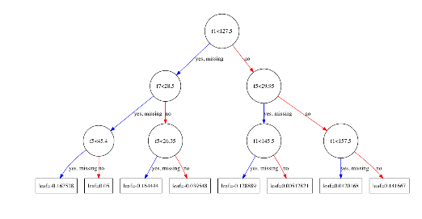

```python
# plot decision tree
from numpy import loadtxt
from xgboost import XGBClassifier
from xgboost import plot_tree
import matplotlib.pyplot as plt

# load data
dataset = loadtxt('pima-indians-diabetes.csv', delimiter=",")

# split data into X and y
X = dataset[:,0:8]
y = dataset[:,8]

# fit model no training data
model = XGBClassifier()
model.fit(X, y)

# plot single tree
plot_tree(model)
plt.show()
```

Running the code creates a plot of the first decision tree in the model (index 0), showing the features and feature values for each split as well as the output leaf nodes.

You can see that variables are automatically named like f1 and f5 corresponding with the feature indices in the input array.

You can see the split decisions within each node and the different colors for left and right splits (blue and red).

The **plot_tree()** function takes some parameters. You can plot specific graphs by specifying their index to the **num_trees** argument. For example, you can plot the 5th boosted tree in the sequence as follows:

```
plot_tree(model, num_trees=4)
```

You can also change the layout of the graph to be left to right (easier to read) by changing the rankdir argument as ‘LR’ (left-to-right) rather than the default top to bottom (UT). For example:

```
plot_tree(model, num_trees=0, rankdir='LR')
```

The result of plotting the tree in the left-to-right layout is shown below.

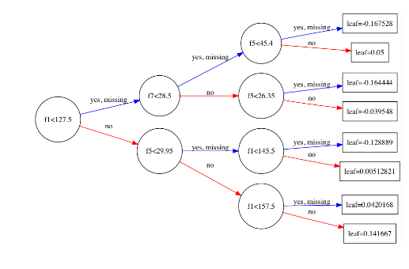

```python
# plot decision tree
from numpy import loadtxt
from xgboost import XGBClassifier
from xgboost import plot_tree
import matplotlib.pyplot as plt

# load data
dataset = loadtxt('pima-indians-diabetes.csv', delimiter=",")

# split data into X and y
X = dataset[:,0:8]
y = dataset[:,8]

# fit model no training data
model = XGBClassifier()
model.fit(X, y)

# plot single tree
plot_tree(model, num_trees=0, rankdir='LR')
plt.show()
```